# Data 602 - In Class Notes for October 5

**Time to Play With Data 1 (Permutation Test)**

Using the code provided in class:

**(a)** The statistical hypothesis is that

$$\begin{eqnarray}
{\rm H}_{0}& : &\text{The differences between the two sample
means are the result of randomness} \hspace{0.2in} \mu_{300mg} =
\mu_{600mg} \\
{\rm H}_{A}& : & \text{The differences between the two sample
means are NOT the result of randomness, but rather due to the difference
in the dosage} \hspace{0.2in} \mu_{300mg} > \mu_{600mg}
\end{eqnarray}$$
If the 600 mg dose is more effective, than the
$$\mu_{300mg} > \mu_{600mg} \longrightarrow \mu_{300mg} - \mu_{600mg}
> 0$$

```r
mg300 = c(284, 279, 289, 292, 287, 295,  285, 279, 306, 298)
mg600 = c(298, 307, 297, 279, 291, 335, 299, 300, 306, 291)
p24levels = c(mg300, mg600)
treat = c(rep("300mg", 10), rep("600mg", 10))
hivdata = data.frame(treat, p24levels)
dim(hivdata)
```

```
[1] 20  2
```

```r
head(hivdata, 4)
```

|  | treat | p24levels |
| --- | --- | --- |
| 1 | 300mg | 284 |
| 2 | 300mg | 279 |
| 3 | 300mg | 289 |
| 4 | 300mg | 292 |

```r
favstats(~ p24levels | treat, data=hivdata) #computes the various statistics broken down by dose
```

| treat | min | Q1 | median | Q3 | max | mean | sd | n | missing |
| --- | --- | --- | --- | --- | --- | --- | --- | --- | --- |
| 300mg | 279 | 284.25 | 288.0 | 294.25 | 306 | 289.4 | 8.553102 | 10 | 0 |
| 600mg | 279 | 292.50 | 298.5 | 304.50 | 335 | 300.3 | 14.629119 | 10 | 0 |

**(b)**

```r
p24diff = mean(~p24levels, data=filter(hivdata, treat=="300mg"))  - mean(~p24levels, data=filter(hivdata, treat=="600mg")) #computes diff in sample means, consistent with the difference in pop means
p24diff  #mean(300mg) - mean(600mg)
```

```
[1] -10.9
```

The observed difference is $\overline{X}_{300mg} - \overline{X}_{600mg} = -10.9$

**(c)**

The code below generates 2000 permutation tests:

```r
nperms <- 2000
perm.outcome <- numeric(nperms)
mean.300mg <- numeric(nperms)
mean.600mg <- numeric(nperms)
for(i in 1:nperms){
  index <- sample(1:20, 10, replace=FALSE)
  mean.300mg[i] <- mean(hivdata$p24levels[index])
  mean.600mg[i] <- mean(hivdata$p24levels[-index])
  perm.outcome[i] <- mean.300mg[i] - mean.600mg[i]
}
```

```r
oct6.permutationtest1 <- data.frame(mean.300mg, mean.600mg, perm.outcome)
```

```r
head(oct6.permutationtest1, 4)
```

|  | mean.300mg | mean.600mg | perm.outcome |
| --- | --- | --- | --- |
| 1 | 293.2 | 296.5 | -3.3 |
| 2 | 294.4 | 295.3 | -0.9 |
| 3 | 293.1 | 296.6 | -3.5 |
| 4 | 294.9 | 294.8 | 0.1 |

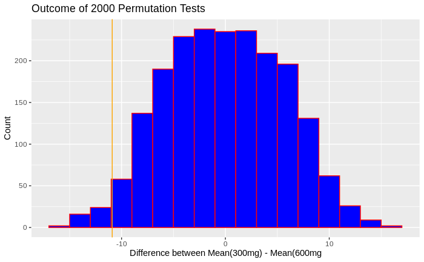

```r
ggplot(oct6.permutationtest1, aes(x = perm.outcome)) + geom_histogram(col="red", fill="blue", binwidth=2) + xlab("Difference between Mean(300mg) - Mean(600mg") + ylab("Count") + ggtitle("Outcome of 2000 Permutation Tests") + geom_vline(xintercept = p24diff, col="orange")
```

**(d)** What is the *empirical* $P$-value? It is **0.9815**.

```r
(sum(oct6.permutationtest1$perm.outcome >= p24diff))/2000
```

Now, if one were to test the idea that $\mu_{300mg} < \mu_{600mg}$, then the empirical $P$-value is

```r
(sum(oct6.permutationtest1$perm.outcome < p24diff))/2000
```

or $0.0185$

**Time to Play With Data 2:** Using previously encounted data….

```r
fibredata = read.csv("http://people.ucalgary.ca/~jbstall/DataFiles/dieteffects.csv") #read the data from .csv into data frame
head(fibredata, 4) #the first 4 rows
```

|  | diet | caloricintake |
| --- | --- | --- |
| 1 | hf | 568 |
| 2 | hf | 498 |
| 3 | hf | 589 |
| 4 | hf | 681 |

```r
tail(fibredata, 4)
```

|  | diet | caloricintake |
| --- | --- | --- |
| 147 | nohf | 596 |
| 148 | nohf | 750 |
| 149 | nohf | 582 |
| 150 | nohf | 788 |

Inquiry? Does caloric intake *decrease* for persons who have a high-fibre (hf) breakfase? The statistical hypothesis is

$${\rm H}_{0}: \mu_{CaloricIntake, hf} = \mu_{CaloricIntake, no\_hf}
\equiv (\mu_{CaloricIntake, hf} - \mu_{CaloricIntake, no\_hf} = 0) \\
{\rm H}_{A}: \mu_{CaloricIntake, hf} < \mu_{CaloricIntake, no\_hf}
\equiv (\mu_{CaloricIntake, hf} - \mu_{CaloricIntake, no\_hf} < 0) \\$$

```r
t.test(~caloricintake|diet, alternative="less", data=fibredata)
```

```
    Welch Two Sample t-test

data:  caloricintake by diet
t = -2.0911, df = 122.6, p-value = 0.01929
alternative hypothesis: true difference in means between group hf and group nohf is less than 0
95 percent confidence interval:
      -Inf -6.058336
sample estimates:
  mean in group hf mean in group nohf
          604.0233           633.2336
```

```r
pt(-2.0911, 122)
```

[output not shown]

from this output,

If the null hypothesis is true, there is a $0.01929$ probability of another data collection method will produce more condemning “numerical evidence” against the null hypothesis than the present data/sample.

**Time to Play With Data 3:**

```r
oct6ttp3.df = read.csv("http://people.ucalgary.ca/~jbstall/DataFiles/studentsurvey.csv")
head(oct6ttp3.df, 4)

fees <- select(oct6ttp3.df, Gender, DiffFees)  # 0 - male, 1 - female; 0 - do not support, 1 - support
head(fees, 4)
```

```r
table(fees$Gender, fees$DiffFees)
#Or
tally(~Gender + DiffFees, margins=TRUE, data=oct6ttp3.df) #margins = TRUE provides the categorical variable names
```

[output not shown]

Gender is the rows, support differential tuition fees are the columns..

The statistical hypothesis to be tested is

$${\rm H}_{0}: p_{M} = p_{F} \longrightarrow p_{m} - p_{f} = 0
\hspace{0.1in} \text{the proportions are the same, indicating there is
no relationship between sex and one's view on differential fees} \\
{\rm H}_{A}: p_{M} \ne p_{F} \longrightarrow p_{m} - p_{f} \ne 0
\hspace{0.1in} \text{the proportions are NOT the same, indicating there
IS relationship between sex and one's view on differential fees} \\$$
To compute the value of the test statistic, I am going to use `prop.test`

```r
prop.test(c(29, 26), c(51, 58), alternative="two.sided", correct=FALSE)
```

[output not shown]

```r
sqrt(1.5724)
```

from which
$$Z_{Obs} = \pm \sqrt{\chi^{2}_{Obs}} = + \sqrt{1.5724} = +1.253954$$
$P$-value = $P(Z > Z_{Obs})*2$.

```r
(1 - pnorm(1.253954))*2
```

and

$$P-\text{value} = 0.20986 \approx 0.2099$$

**Time to Play With Data A:**

**(a)**

```r
oct6ttp1.df <- read.csv("https://people.ucalgary.ca//~jbstall//DataFiles//baseball.csv")
```

```r
oct6ttp1.df = oct6ttp1.df %>%
  mutate(winpct = wins/(wins + losses))
```

```r
head(oct6ttp1.df, 4)
tail(oct6ttp1.df, 4)
```

The scatterplot of the two variables **winpct** and average home **attendance** is provided below, where **attendance** is the total season attendance @ home games for a MLB team.

```r
options(scipen=999)
ggplot(oct6ttp1.df, aes(x = winpct, y = attendance)) + geom_point(col="blue", size=1, position = "jitter") + xlab("Winning Percentage") + ylab("Season Attendance at Home Games") + ggtitle("Plot: Winning % to Home Attendance") + geom_smooth(method="lm", col="red")
```

[output not shown]

```r
favstats(~attendance, data=oct6ttp1.df)
favstats(~winpct, data=oct6ttp1.df)
```

**(b)** The correlation coefficient is computed with

```r
cor(~winpct, ~attendance, data=oct6ttp1.df)
```

[output not shown]

and
$$r = 0.436598 \approx 0.4366$$

Note how the sign on $r$ is positive? And note the “numerical value” of $r$…..

**Time to Play With Data B:**

**(a)** Estimate the least squares line that estimates the model
$$SeasonAttendance_{i} = A + B*WinPct_{i} + e_{i}$$

Using the `lm` command:

```r
predict.seasonattendance <- lm(attendance ~ winpct, data = oct6ttp1.df)
```

```r
predict.seasonattendance$coef
```

[output not shown]

**(b)** Winning percentage of **winpct = 0.405**?

$$\begin{eqnarray}
\widehat{SeasonAttendance}_{i} & = & -612607.7 +
(4782137.1*0.405) \\
& = & 1324158 \:\:
\text{persons/fans}
\end{eqnarray}$$

```r
-612607.7 + (4782137.1*0.405)
```

This can be done with the `predict` command:

```r
predict(predict.seasonattendance, data.frame(winpct=0.405))
```

Meaning? Consider all MLB baseball teams that have a winning percentage of 0.405: The mean/average home attendance for such baseball teams is 1324158 persons/fans in a season.

Consider **winpct = 0.608?

```r
predict(predict.seasonattendance, data.frame(winpct=0.608))
```

$$\widehat{SeasonAttendance}_{i} = 2294932 \:\:\text{persons/fans}$$
——————-

**Time to Play With Data C:**

Check the conditions of the model.

In this instance, I am going create a data frame called **ttpdiagnostic.df**:

```r
attendance.fits <- predict.seasonattendance$fitted.values #assigns predicted values to one vector
attendance.values <- oct6ttp1.df$attendance #assigns observed values of y to another vector
attendance.residuals <- predict.seasonattendance$residuals #assigns residuals to another vectdor
```

```r
ttpdiagnostic.df <- data.frame(attendance.fits, attendance.values, attendance.residuals)
```

```r
ttpdiagnostic.df
```

**(a)** A Normal probability plot of the residuals

```r
ggplot(ttpdiagnostic.df, aes(sample = attendance.residuals)) + stat_qq(col="blue", size = 1) + stat_qqline(col="red") + ggtitle("Normal Probability Plot of Residuals/Error Terms")
```

[output not shown]

This checks the condition of *normalcy* in the residuals - AKA, the $y$-variable home season attendance fluctuates from one team to the next in accordance with a Normal distribution.

**(b)**

A residual plot:

```r
ggplot(ttpdiagnostic.df, aes(x = attendance.fits, y = attendance.residuals)) + geom_point(col="blue", size=1) + xlab("Predicted Values of Home Attendance in a Season") + ylab("Residuals") + ggtitle("Residual Plot") + geom_hline(yintercept=0, col="red", linetype="dashed")
```

[output not shown]

**Time to Play With Data D:**

1. Compute the value of $S_{e}$, which is used to estimate the common standard deviation $\sigma$ in the $y$-variable (home season attendance), regardless of the value of the $x$-variable (winning percentage)

```r
sum(ttpdiagnostic.df$attendance.residuals^2)
sqrt(sum(ttpdiagnostic.df$attendance.residuals^2)/(838 - 2))  #note, n = 838
```

[output not shown]

from which

$$S_{e} = \sqrt{\frac{SSE}{n - 2}} = \sqrt{\frac{ 387058460537948}{838 -
2}} = 680432.6$$
Alternatively, this can be obtained with the `aov` function

```r
aov(predict.seasonattendance)
```

[output not shown]

from which
$$SSR = 91156224715423 \hspace{0.5in} \text{and} \hspace{0.5in} SSE =
387058460537948 \hspace{0.5in} S_{e} = 680432.6$$

The coefficient of determination $r^{2}$ is

```r
rsquared(predict.seasonattendance)
```

[output not shown]

and
$$r^{2} = \frac{91156224715423}{91156224715423 + 387058460537948} =
0.1906178$$

19.06% of the variation in the season attendance can be explained by its linear relationship with/dependency on the MLB team’s winning percentage.